```r
library(data.table)
library(plotly, quietly = TRUE)
library(scatterplot3d,  quietly = TRUE)
library(data.table,  quietly = TRUE)
library(dplyr,  quietly = TRUE)
library(ggfortify)
```

```r
x_train=fread("uWaveGestureLibrary_X_TRAIN")
x_test=fread("uWaveGestureLibrary_X_TEST")
y_train=fread("uWaveGestureLibrary_Y_TRAIN")
y_test=fread("uWaveGestureLibrary_Y_TEST")
z_train=fread("uWaveGestureLibrary_Z_TRAIN")
z_test=fread("uWaveGestureLibrary_Z_TEST")

class1_ind<-which(x_train$V1==1)[1:2]
class2_ind<-which(x_train$V1==2)[1:2]
class3_ind<-which(x_train$V1==3)[1:2]
class4_ind<-which(x_train$V1==4)[1:2]
class5_ind<-which(x_train$V1==5)[1:2]
class6_ind<-which(x_train$V1==6)[1:2]
class7_ind<-which(x_train$V1==7)[1:2]
class8_ind<-which(x_train$V1==8)[1:2]
indexes<-c(class1_ind,class2_ind,class3_ind,class4_ind,class5_ind,class6_ind,class7_ind,class8_ind)
```

# PART A

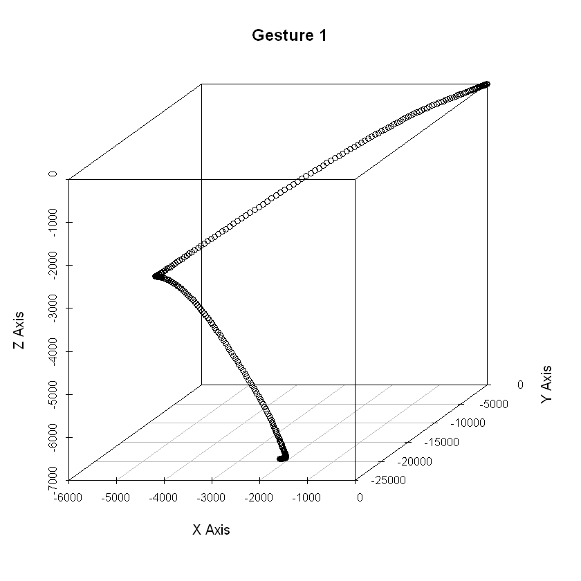

```r
gesture <- data.table(x=t(x_train[indexes[1],-1]),
                      y=t(y_train[indexes[1],-1]),
                      z=t(z_train[indexes[1],-1]))
names(gesture)[names(gesture) == "x.V1"] <- "x"
names(gesture)[names(gesture) == "y.V1"] <- "y"
names(gesture)[names(gesture) == "z.V1"] <- "z"
gesture$x_v=cumsum(gesture$x)
gesture$y_v=cumsum(gesture$y)
gesture$z_v=cumsum(gesture$z)
gesture$x_location=cumsum(gesture$x_v)
gesture$y_location=cumsum(gesture$y_v)
gesture$z_location=cumsum(gesture$z_v)
scatterplot3d(gesture$x_location,gesture$y_location,gesture$z_location, xlab = "X Axis", ylab = "Y Axis",
              zlab = "Z Axis", main="Gesture 1")
```

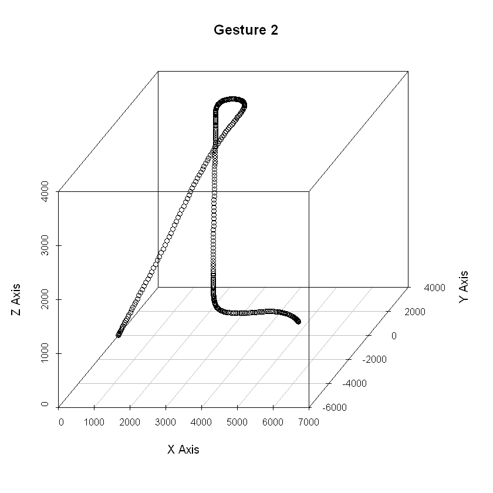

```r
gesture <- data.table(x=t(x_train[indexes[3],-1]),
                      y=t(y_train[indexes[3],-1]),
                      z=t(z_train[indexes[3],-1]))
names(gesture)[names(gesture) == "x.V1"] <- "x"
names(gesture)[names(gesture) == "y.V1"] <- "y"
names(gesture)[names(gesture) == "z.V1"] <- "z"
gesture$x_v=cumsum(gesture$x)
gesture$y_v=cumsum(gesture$y)
gesture$z_v=cumsum(gesture$z)
gesture$x_location=cumsum(gesture$x_v)
gesture$y_location=cumsum(gesture$y_v)
gesture$z_location=cumsum(gesture$z_v)
scatterplot3d(gesture$x_location,gesture$y_location,gesture$z_location, xlab = "X Axis", ylab = "Y Axis",
              zlab = "Z Axis", main="Gesture 2")
```

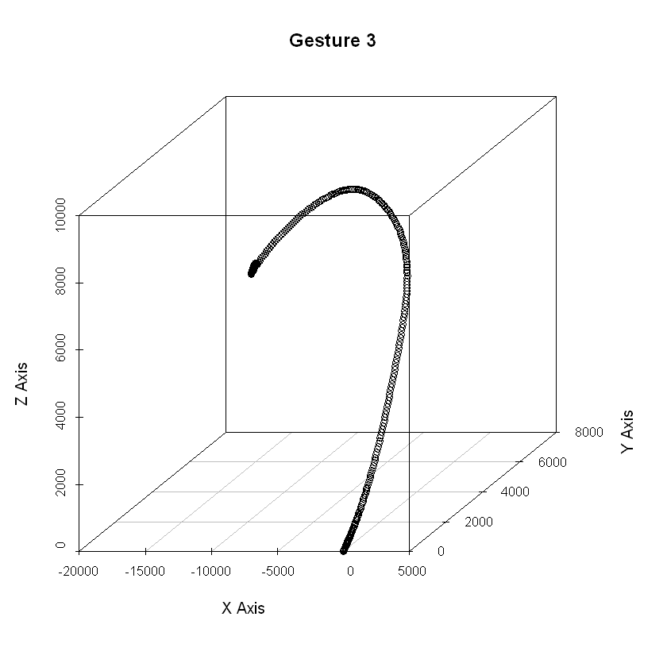

```r
gesture <- data.table(x=t(x_train[indexes[5],-1]),
                      y=t(y_train[indexes[5],-1]),
                      z=t(z_train[indexes[5],-1]))
names(gesture)[names(gesture) == "x.V1"] <- "x"
names(gesture)[names(gesture) == "y.V1"] <- "y"
names(gesture)[names(gesture) == "z.V1"] <- "z"
gesture$x_v=cumsum(gesture$x)
gesture$y_v=cumsum(gesture$y)
gesture$z_v=cumsum(gesture$z)
gesture$x_location=cumsum(gesture$x_v)
gesture$y_location=cumsum(gesture$y_v)
gesture$z_location=cumsum(gesture$z_v)
scatterplot3d(gesture$x_location,gesture$y_location,gesture$z_location, xlab = "X Axis", ylab = "Y Axis",
              zlab = "Z Axis", main="Gesture 3")
```

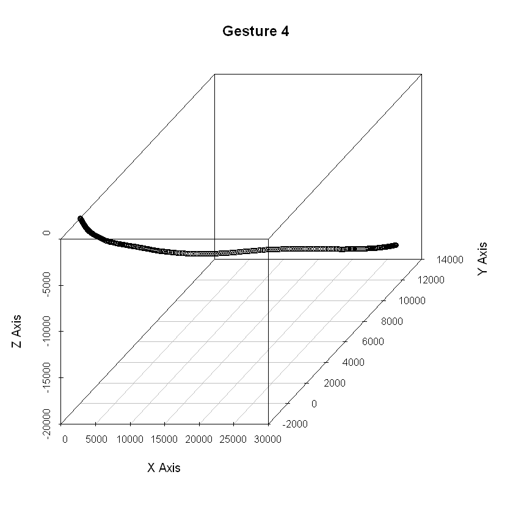

```r
gesture <- data.table(x=t(x_train[indexes[7],-1]),
                      y=t(y_train[indexes[7],-1]),
                      z=t(z_train[indexes[7],-1]))
names(gesture)[names(gesture) == "x.V1"] <- "x"
names(gesture)[names(gesture) == "y.V1"] <- "y"
names(gesture)[names(gesture) == "z.V1"] <- "z"
gesture$x_v=cumsum(gesture$x)
gesture$y_v=cumsum(gesture$y)
gesture$z_v=cumsum(gesture$z)
gesture$x_location=cumsum(gesture$x_v)
gesture$y_location=cumsum(gesture$y_v)
gesture$z_location=cumsum(gesture$z_v)
scatterplot3d(gesture$x_location,gesture$y_location,gesture$z_location, xlab = "X Axis", ylab = "Y Axis",
              zlab = "Z Axis", main="Gesture 4")
```

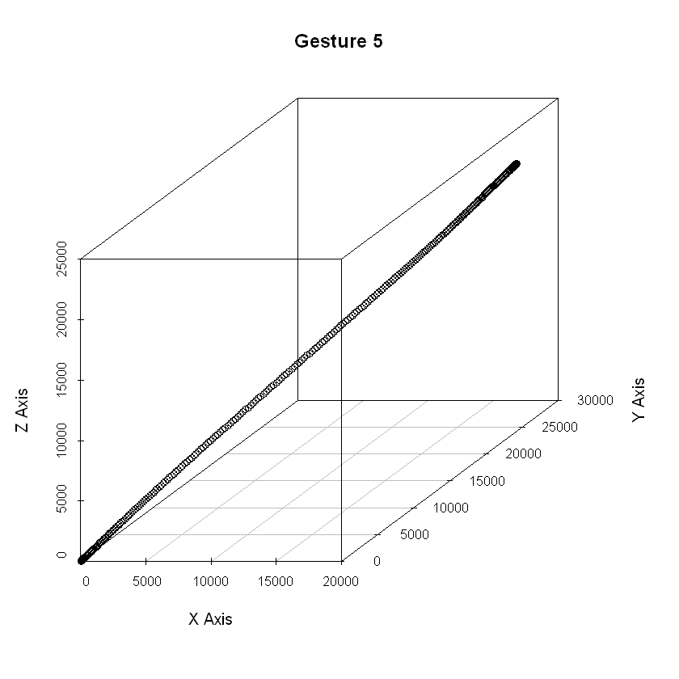

```r
gesture <- data.table(x=t(x_train[indexes[9],-1]),
                      y=t(y_train[indexes[9],-1]),
                      z=t(z_train[indexes[9],-1]))
names(gesture)[names(gesture) == "x.V1"] <- "x"
names(gesture)[names(gesture) == "y.V1"] <- "y"
names(gesture)[names(gesture) == "z.V1"] <- "z"
gesture$x_v=cumsum(gesture$x)
gesture$y_v=cumsum(gesture$y)
gesture$z_v=cumsum(gesture$z)
gesture$x_location=cumsum(gesture$x_v)
gesture$y_location=cumsum(gesture$y_v)
gesture$z_location=cumsum(gesture$z_v)
scatterplot3d(gesture$x_location,gesture$y_location,gesture$z_location, xlab = "X Axis", ylab = "Y Axis",
              zlab = "Z Axis", main="Gesture 5")
```

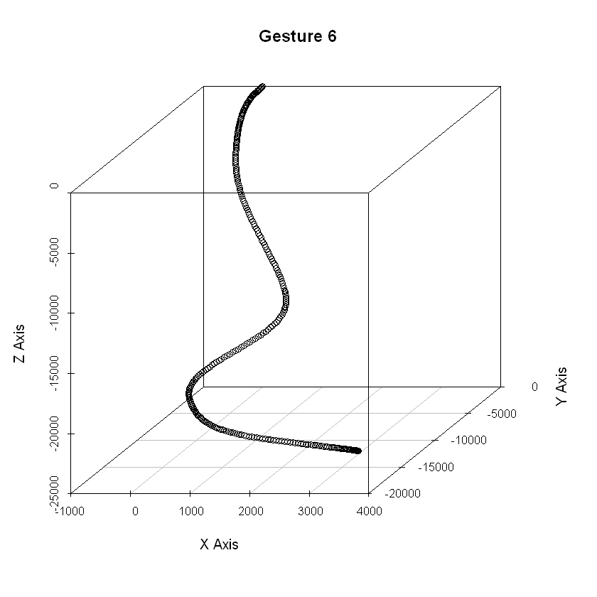

```r
gesture <- data.table(x=t(x_train[indexes[11],-1]),
                      y=t(y_train[indexes[11],-1]),
                      z=t(z_train[indexes[11],-1]))
names(gesture)[names(gesture) == "x.V1"] <- "x"
names(gesture)[names(gesture) == "y.V1"] <- "y"
names(gesture)[names(gesture) == "z.V1"] <- "z"
gesture$x_v=cumsum(gesture$x)
gesture$y_v=cumsum(gesture$y)
gesture$z_v=cumsum(gesture$z)
gesture$x_location=cumsum(gesture$x_v)
gesture$y_location=cumsum(gesture$y_v)
gesture$z_location=cumsum(gesture$z_v)
scatterplot3d(gesture$x_location,gesture$y_location,gesture$z_location, xlab = "X Axis", ylab = "Y Axis",
              zlab = "Z Axis", main="Gesture 6")
```

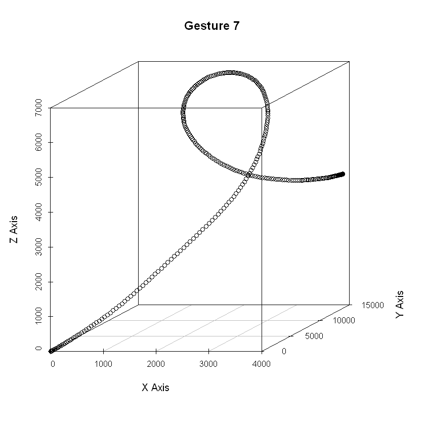

```r
gesture <- data.table(x=t(x_train[indexes[13],-1]),
                      y=t(y_train[indexes[13],-1]),
                      z=t(z_train[indexes[13],-1]))
names(gesture)[names(gesture) == "x.V1"] <- "x"
names(gesture)[names(gesture) == "y.V1"] <- "y"
names(gesture)[names(gesture) == "z.V1"] <- "z"
gesture$x_v=cumsum(gesture$x)
gesture$y_v=cumsum(gesture$y)
gesture$z_v=cumsum(gesture$z)
gesture$x_location=cumsum(gesture$x_v)
gesture$y_location=cumsum(gesture$y_v)
gesture$z_location=cumsum(gesture$z_v)
scatterplot3d(gesture$x_location,gesture$y_location,gesture$z_location, xlab = "X Axis", ylab = "Y Axis",
              zlab = "Z Axis", main="Gesture 7")
```

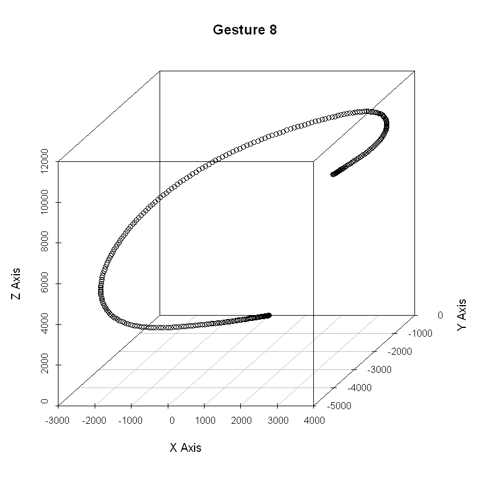

```r
gesture <- data.table(x=t(x_train[indexes[15],-1]),
                      y=t(y_train[indexes[15],-1]),
                      z=t(z_train[indexes[15],-1]))
names(gesture)[names(gesture) == "x.V1"] <- "x"
names(gesture)[names(gesture) == "y.V1"] <- "y"
names(gesture)[names(gesture) == "z.V1"] <- "z"
gesture$x_v=cumsum(gesture$x)
gesture$y_v=cumsum(gesture$y)
gesture$z_v=cumsum(gesture$z)
gesture$x_location=cumsum(gesture$x_v)
gesture$y_location=cumsum(gesture$y_v)
gesture$z_location=cumsum(gesture$z_v)
scatterplot3d(gesture$x_location,gesture$y_location,gesture$z_location, xlab = "X Axis", ylab = "Y Axis",
              zlab = "Z Axis", main="Gesture 8")
```

All gestures are created by location information after asked to professor Baydogan. Location information can be more useful/proper for visualization of gestures.

# Part B

```r
train_xpos=transpose(cumsum(transpose(x_train[,-1])))
train_xpos$class=x_train[,1]
train_xpos<-train_xpos %>%
    mutate("id" = seq.int(nrow(train_xpos)))%>%
    melt(id.vars = c("id","class"),value.name="X")
```

```r
train_ypos=transpose(cumsum(transpose(y_train[,-1])))
train_ypos$class=y_train[,1]
train_ypos<-train_ypos %>%
    mutate("id" = seq.int(nrow(train_ypos)))%>%
    melt(id.vars = c("id","class"),value.name="Y")
```

```r
train_zpos=transpose(cumsum(transpose(z_train[,-1])))
train_zpos$class=z_train[,1]
train_zpos<-train_zpos %>%
    mutate("id" = seq.int(nrow(train_zpos)))%>%
    melt(id.vars = c("id","class"),value.name="Z")
```

```r
long_form=copy(train_xpos)
long_form$Y=train_ypos$Y
long_form$Z=train_zpos$Z
long_form=long_form[,c(1,3,4,5,6,2)]
long_form$variable=as.integer(long_form$variable)
colnames(long_form)[1] <- "time_series_id"
colnames(long_form)[2] <- "time_index"
setorder(long_form, time_series_id)
```

## Long Format of Dataset

```r
long_form
```

| time_series_id | time_index | X | Y | Z | class |
| --- | --- | --- | --- | --- | --- |
| 1 | 1 | -0.3042432 | -2.119396 | -1.528965 | 6 |
| 1 | 2 | -0.6084864 | -4.238792 | -3.057930 | 6 |
| 1 | 3 | -0.9127296 | -6.358187 | -4.586895 | 6 |
| 1 | 4 | -1.2169728 | -8.477583 | -6.115860 | 6 |
| 1 | 5 | -1.5212161 | -10.596979 | -7.644825 | 6 |
| 1 | 6 | -1.8254593 | -12.716375 | -9.173791 | 6 |
| 1 | 7 | -2.1297025 | -14.835771 | -10.702756 | 6 |
| 1 | 8 | -2.4339457 | -16.955166 | -12.231721 | 6 |
| 1 | 9 | -2.7381889 | -19.074562 | -13.760686 | 6 |
| 1 | 10 | -3.0424321 | -21.193958 | -15.289651 | 6 |
| 1 | 11 | -3.3466753 | -23.313354 | -16.818616 | 6 |
| 1 | 12 | -3.6509185 | -25.432750 | -18.347581 | 6 |
| 1 | 13 | -3.9551617 | -27.552145 | -19.876546 | 6 |
| 1 | 14 | -4.2594049 | -29.671541 | -21.405511 | 6 |
| 1 | 15 | -4.5636481 | -31.790937 | -22.934476 | 6 |
| 1 | 16 | -4.8678914 | -33.910333 | -24.463442 | 6 |
| 1 | 17 | -5.1721346 | -36.029729 | -25.992407 | 6 |
| 1 | 18 | -5.4763778 | -38.149124 | -27.521372 | 6 |
| 1 | 19 | -5.7806210 | -40.268520 | -29.050337 | 6 |
| 1 | 20 | -6.0214288 | -42.320079 | -30.568604 | 6 |
| 1 | 21 | -6.1988012 | -44.303802 | -32.076173 | 6 |
| 1 | 22 | -6.2668023 | -46.170565 | -33.565297 | 6 |
| 1 | 23 | -6.2254321 | -47.920368 | -35.035976 | 6 |
| 1 | 24 | -6.0746906 | -49.553212 | -36.488211 | 6 |
| 1 | 25 | -5.8145777 | -51.069096 | -37.922000 | 6 |
| 1 | 26 | -5.4932169 | -52.519483 | -39.345460 | 6 |
| 1 | 27 | -5.1106082 | -53.904373 | -40.758591 | 6 |
| 1 | 28 | -4.7279994 | -55.289262 | -42.171722 | 6 |
| 1 | 29 | -4.3453906 | -56.674151 | -43.584853 | 6 |
| 1 | 30 | -3.9627819 | -58.059041 | -44.997984 | 6 |
| ... | ... | ... | ... | ... | ... |
| 896 | 286 | -2.403886e+01 | 33.469229882 | 26.353375476 | 5 |
| 896 | 287 | -2.402462e+01 | 32.059645082 | 25.427868686 | 5 |
| 896 | 288 | -2.410924e+01 | 30.666456182 | 24.491841276 | 5 |
| 896 | 289 | -2.426033e+01 | 29.284288282 | 23.548742156 | 5 |
| 896 | 290 | -2.442885e+01 | 27.905011182 | 22.603788166 | 5 |
| 896 | 291 | -2.459736e+01 | 26.525734082 | 21.658834176 | 5 |
| 896 | 292 | -2.475294e+01 | 25.148602382 | 20.712503526 | 5 |
| 896 | 293 | -2.482960e+01 | 23.784558182 | 19.757775216 | 5 |
| 896 | 294 | -2.480913e+01 | 22.436621982 | 18.792711056 | 5 |
| 896 | 295 | -2.468896e+01 | 21.105217282 | 17.818604386 | 5 |
| 896 | 296 | -2.446910e+01 | 19.790344082 | 16.838954826 | 5 |
| 896 | 297 | -2.414956e+01 | 18.492002282 | 15.859305266 | 5 |
| 896 | 298 | -2.373033e+01 | 17.210191982 | 14.879655706 | 5 |
| 896 | 299 | -2.321140e+01 | 15.944913182 | 13.905487446 | 5 |
| 896 | 300 | -2.259279e+01 | 14.696165882 | 12.940202296 | 5 |
| 896 | 301 | -2.187190e+01 | 13.464808182 | 11.985800046 | 5 |
| 896 | 302 | -2.103470e+01 | 12.255492482 | 11.043773276 | 5 |
| 896 | 303 | -2.000902e+01 | 11.092157782 | 10.121802336 | 5 |
| 896 | 304 | -1.878396e+01 | 9.978417382 | 9.221046516 | 5 |
| 896 | 305 | -1.739630e+01 | 8.905124882 | 8.337593196 | 5 |
| 896 | 306 | -1.593448e+01 | 7.850277782 | 7.462030346 | 5 |
| 896 | 307 | -1.447266e+01 | 6.795430682 | 6.586467496 | 5 |
| 896 | 308 | -1.299885e+01 | 5.744558382 | 5.711542256 | 5 |
| 896 | 309 | -1.142904e+01 | 4.725529482 | 4.841725166 | 5 |
| 896 | 310 | -9.659839e+00 | 3.772626512 | 3.982515636 | 5 |
| 896 | 311 | -7.691264e+00 | 2.885849442 | 3.133913676 | 5 |
| 896 | 312 | -5.662732e+00 | 2.065198272 | 2.305809516 | 5 |
| 896 | 313 | -3.675465e+00 | 1.310673012 | 1.505383566 | 5 |
| 896 | 314 | -1.787888e+00 | 0.622273652 | 0.736780306 | 5 |
| 896 | 315 | 6.081000e-07 | 0.000000192 | -0.000000274 | 5 |

## Principal Component Analysis

```r
long_form_pca <-prcomp(long_form[,c(3,4,5)], center = TRUE,scale. = TRUE)
long_form_pca
summary(long_form_pca)
```

```
Standard deviations (1, .., p=3):
[1] 1.2548918 1.0329813 0.5984948

Rotation (n x k) = (3 x 3):
        PC1         PC2        PC3
X 0.2325778 -0.90142949  0.3651472
Y 0.7230122 -0.09086505 -0.6848335
Z 0.6505082  0.42328291  0.6306113
```

```
Importance of components:
                          PC1    PC2    PC3
Standard deviation     1.2549 1.0330 0.5985
Proportion of Variance 0.5249 0.3557 0.1194
Cumulative Proportion  0.5249 0.8806 1.0000
```

```r
long_form$class=as.factor(long_form$class)
```

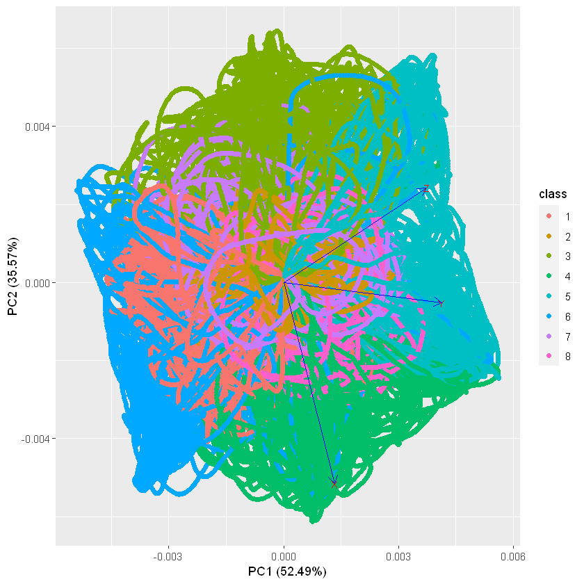

```r
autoplot(long_form_pca, data = long_form, colour = "class",
         loadings = TRUE, loadings.colour = 'blue',
         loadings.label = TRUE, loadings.label.size = 3)
```

```r
class1=filter(long_form, time_series_id == indexes[1] | time_series_id == indexes[2])
class1=mutate(class1, red_dim= 0.2325778 * X + 0.7230122  * Y + 0.6505082   * Z )
class1$time_series_id=as.factor(class1$time_series_id)
class1$time_index=as.integer(class1$time_index)
str(class1)
```

```
Classes 'data.table' and 'data.frame':	630 obs. of  7 variables:
 $ time_series_id: Factor w/ 2 levels "11","17": 1 1 1 1 1 1 1 1 1 1 ...
 $ time_index    : int  1 2 3 4 5 6 7 8 9 10 ...
 $ X             : num  -0.791 -1.583 -2.379 -3.189 -4.038 ...
 $ Y             : num  -1.96 -3.92 -5.88 -7.82 -9.74 ...
 $ Z             : num  -0.249 -0.498 -0.75 -1.009 -1.289 ...
 $ class         : Factor w/ 8 levels "1","2","3","4",..: 1 1 1 1 1 1 1 1 1 1 ...
 $ red_dim       : num  -1.76 -3.53 -5.29 -7.05 -8.82 ...
 - attr(*, ".internal.selfref")=<externalptr>
```

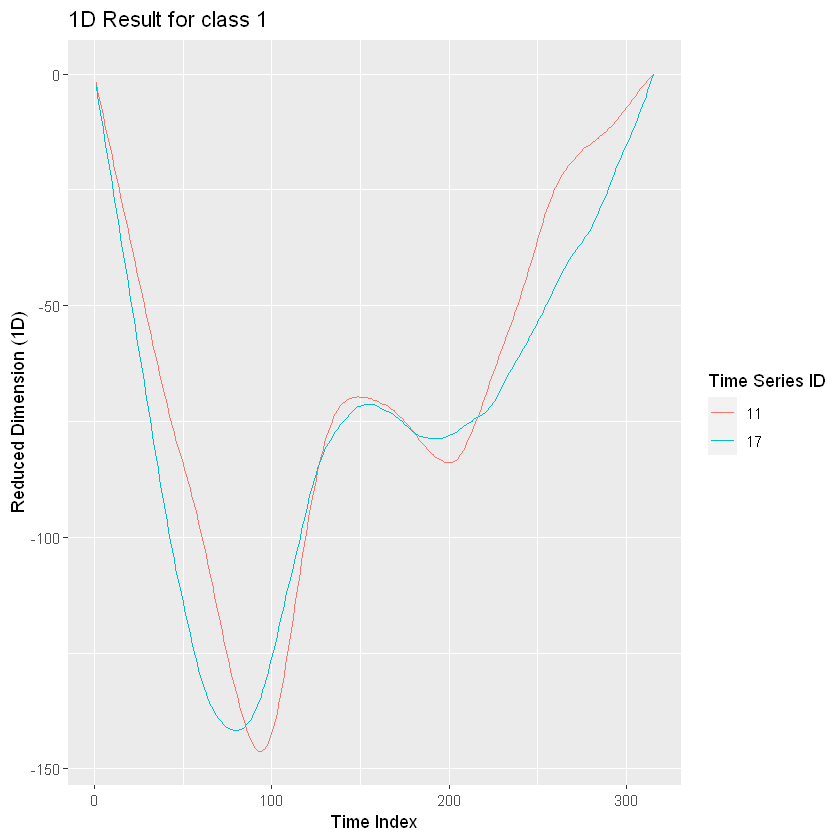

```r
ggplot(data=class1,
       aes(x=time_index, y=red_dim, colour=time_series_id))+
       geom_line()+labs(color="Time Series ID")+xlab("Time Index")+ylab("Reduced Dimension (1D)")+ggtitle("1D Result for class 1")
```

```r
class2=filter(long_form, time_series_id == indexes[3] | time_series_id == indexes[4])
class2=mutate(class2, red_dim= 0.2325778 * X + 0.7230122  * Y + 0.6505082   * Z )
class2$time_series_id=as.factor(class2$time_series_id)
class2$time_index=as.integer(class2$time_index)
str(class2)
```

```
Classes 'data.table' and 'data.frame':	630 obs. of  7 variables:
 $ time_series_id: Factor w/ 2 levels "15","20": 1 1 1 1 1 1 1 1 1 1 ...
 $ time_index    : int  1 2 3 4 5 6 7 8 9 10 ...
 $ X             : num  1.2 2.4 3.63 4.96 6.32 ...
 $ Y             : num  1.63 3.25 4.88 6.51 8.14 ...
 $ Z             : num  1.95 3.9 5.84 7.75 9.64 ...
 $ class         : Factor w/ 8 levels "1","2","3","4",..: 2 2 2 2 2 2 2 2 2 2 ...
 $ red_dim       : num  2.73 5.45 8.18 10.9 13.63 ...
 - attr(*, ".internal.selfref")=<externalptr>
```

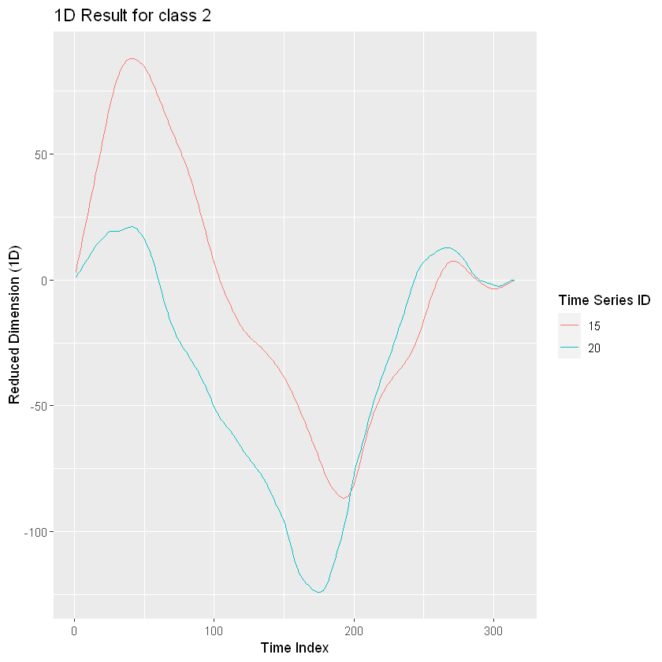

```r
ggplot(data=class2,
       aes(x=time_index, y=red_dim, colour=time_series_id)) +
       geom_line()+labs(color="Time Series ID")+xlab("Time Index")+ylab("Reduced Dimension (1D)")+ggtitle("1D Result for class 2")
```

```r
class3=filter(long_form, time_series_id == indexes[5] | time_series_id == indexes[6])
class3=mutate(class3, red_dim= 0.2325778 * X + 0.7230122  * Y + 0.6505082   * Z )
class3$time_series_id=as.factor(class3$time_series_id)
class3$time_index=as.integer(class3$time_index)
str(class3)
```

```
Classes 'data.table' and 'data.frame':	630 obs. of  7 variables:
 $ time_series_id: Factor w/ 2 levels "4","13": 1 1 1 1 1 1 1 1 1 1 ...
 $ time_index    : int  1 2 3 4 5 6 7 8 9 10 ...
 $ X             : num  0.00518 0.01037 0.01555 0.02074 0.02592 ...
 $ Y             : num  0.374 0.748 1.122 1.496 1.87 ...
 $ Z             : num  0.309 0.619 0.928 1.238 1.547 ...
 $ class         : Factor w/ 8 levels "1","2","3","4",..: 3 3 3 3 3 3 3 3 3 3 ...
 $ red_dim       : num  0.473 0.946 1.419 1.892 2.365 ...
 - attr(*, ".internal.selfref")=<externalptr>
```

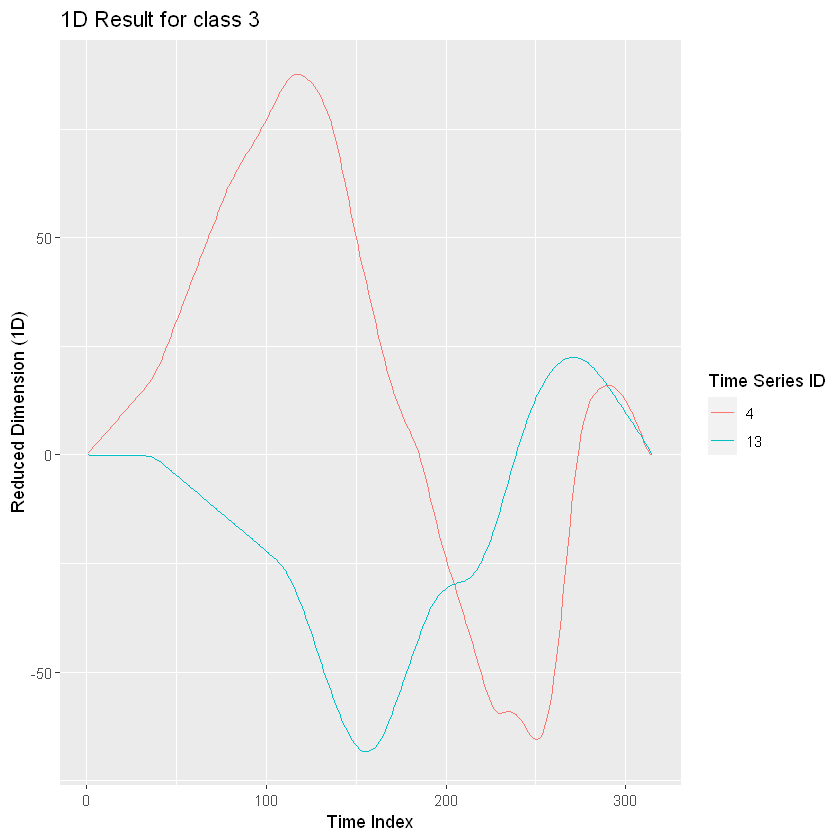

```r
ggplot(data=class3,
       aes(x=time_index, y=red_dim, colour=time_series_id)) +
       geom_line()+labs(color="Time Series ID")+xlab("Time Index")+ylab("Reduced Dimension (1D)")+ggtitle("1D Result for class 3")
```

```r
class4=filter(long_form, time_series_id == indexes[7] | time_series_id == indexes[8])
class4=mutate(class4, red_dim= 0.2325778 * X + 0.7230122  * Y + 0.6505082   * Z )
class4$time_series_id=as.factor(class4$time_series_id)
class4$time_index=as.integer(class4$time_index)
str(class4)
```

```
Classes 'data.table' and 'data.frame':	630 obs. of  7 variables:
 $ time_series_id: Factor w/ 2 levels "5","8": 1 1 1 1 1 1 1 1 1 1 ...
 $ time_index    : int  1 2 3 4 5 6 7 8 9 10 ...
 $ X             : num  1.29 2.57 3.86 5.14 6.43 ...
 $ Y             : num  -0.397 -0.795 -1.192 -1.59 -1.987 ...
 $ Z             : num  -0.466 -0.932 -1.398 -1.864 -2.33 ...
 $ class         : Factor w/ 8 levels "1","2","3","4",..: 4 4 4 4 4 4 4 4 4 4 ...
 $ red_dim       : num  -0.291 -0.583 -0.874 -1.165 -1.457 ...
 - attr(*, ".internal.selfref")=<externalptr>
```

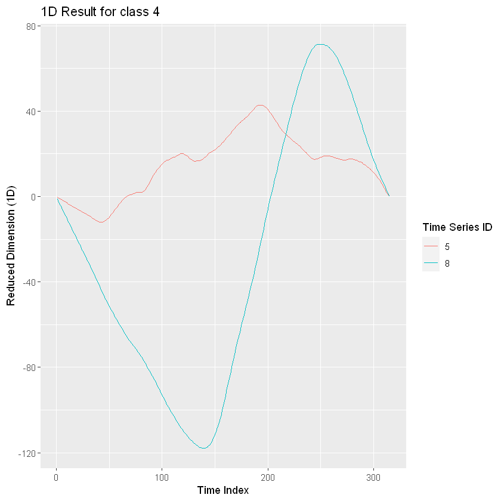

```r
ggplot(data=class4,
       aes(x=time_index, y=red_dim, colour=time_series_id)) +
       geom_line()+labs(color="Time Series ID")+xlab("Time Index")+ylab("Reduced Dimension (1D)")+ggtitle("1D Result for class 4")
```

```r
class5=filter(long_form, time_series_id == indexes[9] | time_series_id == indexes[10])
class5=mutate(class5, red_dim= 0.2325778 * X + 0.7230122  * Y + 0.6505082   * Z )
class5$time_series_id=as.factor(class5$time_series_id)
class5$time_index=as.integer(class5$time_index)
str(class5)
```

```
Classes 'data.table' and 'data.frame':	630 obs. of  7 variables:
 $ time_series_id: Factor w/ 2 levels "2","3": 1 1 1 1 1 1 1 1 1 1 ...
 $ time_index    : int  1 2 3 4 5 6 7 8 9 10 ...
 $ X             : num  1.63 3.25 4.88 6.51 8.14 ...
 $ Y             : num  0.667 1.333 2 2.666 3.333 ...
 $ Z             : num  1.79 3.57 5.36 7.15 8.93 ...
 $ class         : Factor w/ 8 levels "1","2","3","4",..: 5 5 5 5 5 5 5 5 5 5 ...
 $ red_dim       : num  2.02 4.05 6.07 8.09 10.11 ...
 - attr(*, ".internal.selfref")=<externalptr>
```

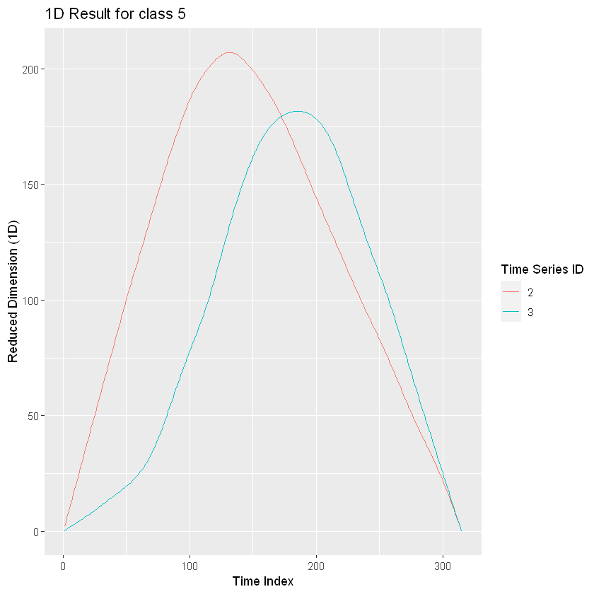

```r
ggplot(data=class5,
       aes(x=time_index, y=red_dim, colour=time_series_id)) +
       geom_line()+labs(color="Time Series ID")+xlab("Time Index")+ylab("Reduced Dimension (1D)")+ggtitle("1D Result for class 5")
```

```r
class6=filter(long_form, time_series_id == indexes[11] | time_series_id == indexes[12])
class6=mutate(class6, red_dim= 0.2325778 * X + 0.7230122  * Y + 0.6505082   * Z )
class6$time_series_id=as.factor(class6$time_series_id)
class6$time_index=as.integer(class6$time_index)
str(class6)
```

```
Classes 'data.table' and 'data.frame':	630 obs. of  7 variables:
 $ time_series_id: Factor w/ 2 levels "1","10": 1 1 1 1 1 1 1 1 1 1 ...
 $ time_index    : int  1 2 3 4 5 6 7 8 9 10 ...
 $ X             : num  -0.304 -0.608 -0.913 -1.217 -1.521 ...
 $ Y             : num  -2.12 -4.24 -6.36 -8.48 -10.6 ...
 $ Z             : num  -1.53 -3.06 -4.59 -6.12 -7.64 ...
 $ class         : Factor w/ 8 levels "1","2","3","4",..: 6 6 6 6 6 6 6 6 6 6 ...
 $ red_dim       : num  -2.6 -5.2 -7.79 -10.39 -12.99 ...
 - attr(*, ".internal.selfref")=<externalptr>
```

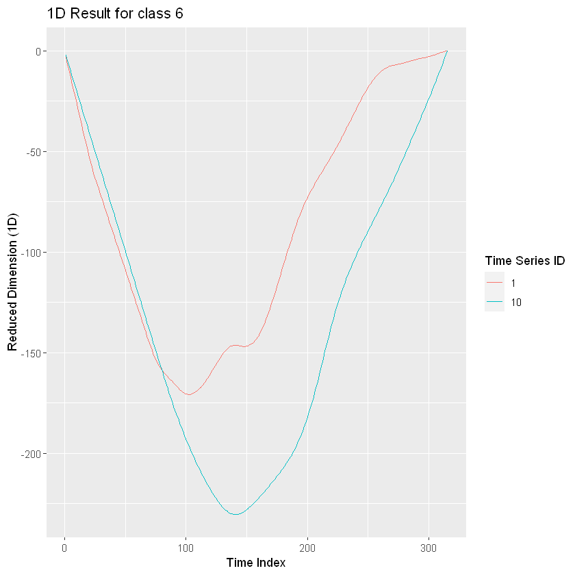

```r
ggplot(data=class6,
       aes(x=time_index, y=red_dim, colour=time_series_id)) +
       geom_line()+labs(color="Time Series ID")+xlab("Time Index")+ylab("Reduced Dimension (1D)")+ggtitle("1D Result for class 6")
```

```r
class7=filter(long_form, time_series_id == indexes[13] | time_series_id == indexes[14])
class7=mutate(class7, red_dim= 0.2325778 * X + 0.7230122  * Y + 0.6505082   * Z )
class7$time_series_id=as.factor(class7$time_series_id)
class7$time_index=as.integer(class7$time_index)
str(class7)
```

```
Classes 'data.table' and 'data.frame':	630 obs. of  7 variables:
 $ time_series_id: Factor w/ 2 levels "7","12": 1 1 1 1 1 1 1 1 1 1 ...
 $ time_index    : int  1 2 3 4 5 6 7 8 9 10 ...
 $ X             : num  1.47 2.95 4.42 5.9 7.37 ...
 $ Y             : num  1.26 2.52 3.78 5.04 6.3 ...
 $ Z             : num  1.24 2.47 3.71 4.95 6.19 ...
 $ class         : Factor w/ 8 levels "1","2","3","4",..: 7 7 7 7 7 7 7 7 7 7 ...
 $ red_dim       : num  2.06 4.12 6.17 8.23 10.29 ...
 - attr(*, ".internal.selfref")=<externalptr>
```

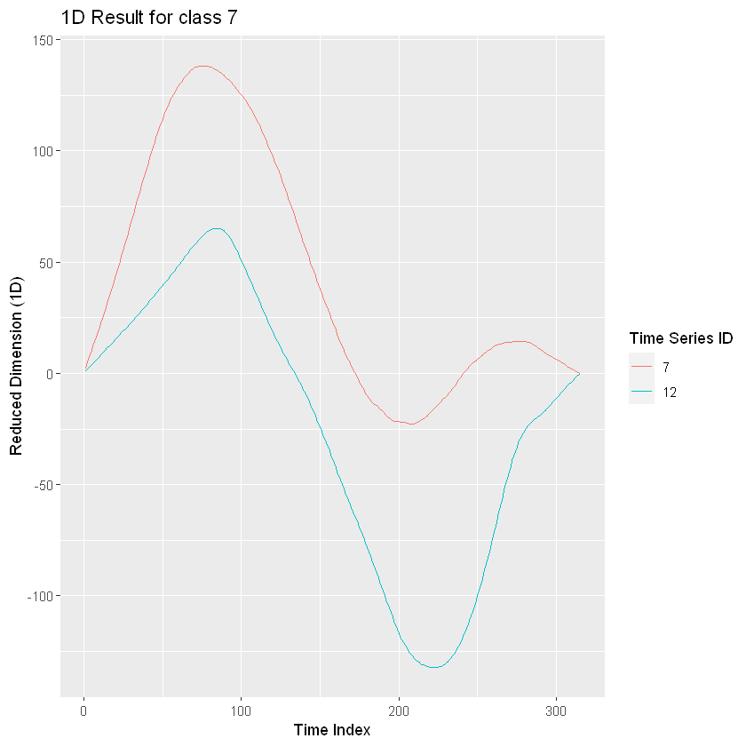

```r
ggplot(data=class7,
       aes(x=time_index, y=red_dim, colour=time_series_id)) +
       geom_line()+labs(color="Time Series ID")+xlab("Time Index")+ylab("Reduced Dimension (1D)")+ggtitle("1D Result for class 7")
```

```r
class8=filter(long_form, time_series_id == indexes[15] | time_series_id == indexes[16])
class8=mutate(class8, red_dim= 0.2325778 * X + 0.7230122  * Y + 0.6505082   * Z )
class8$time_series_id=as.factor(class8$time_series_id)
class8$time_index=as.integer(class8$time_index)
str(class8)
```

```
Classes 'data.table' and 'data.frame':	630 obs. of  7 variables:
 $ time_series_id: Factor w/ 2 levels "6","21": 1 1 1 1 1 1 1 1 1 1 ...
 $ time_index    : int  1 2 3 4 5 6 7 8 9 10 ...
 $ X             : num  -0.479 -0.959 -1.438 -1.917 -2.396 ...
 $ Y             : num  -1.08 -2.16 -3.24 -4.32 -5.4 ...
 $ Z             : num  0.656 1.313 1.969 2.626 3.282 ...
 $ class         : Factor w/ 8 levels "1","2","3","4",..: 8 8 8 8 8 8 8 8 8 8 ...
 $ red_dim       : num  -0.465 -0.931 -1.396 -1.862 -2.327 ...
 - attr(*, ".internal.selfref")=<externalptr>
```

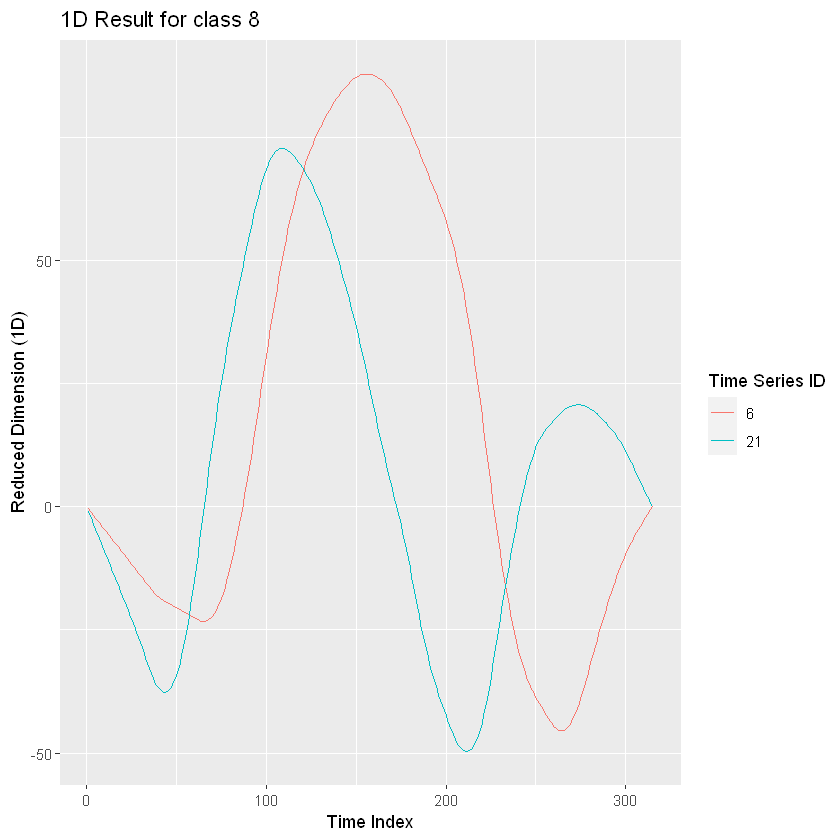

```r
ggplot(data=class8,
       aes(x=time_index, y=red_dim, colour=time_series_id)) +
       geom_line()+labs(color="Time Series ID")+xlab("Time Index")+ylab("Reduced Dimension (1D)")+ggtitle("1D Result for class 8")
```

# Part C

```r
class1_filtered<-filter(long_form, class == 1)
class2_filtered<-filter(long_form, class == 2)
class3_filtered<-filter(long_form, class == 3)
class4_filtered<-filter(long_form, class == 4)
class5_filtered<-filter(long_form, class == 5)
class6_filtered<-filter(long_form, class == 6)
class7_filtered<-filter(long_form, class == 7)
class8_filtered<-filter(long_form, class == 8)
```

All the Time Series are filtered by looking class information. 8 different data.frame achieved at the end.

```r
pca_class1 <-prcomp(class1_filtered[,c(3,4,5)], center = TRUE,scale. = TRUE)
pca_class1
summary(pca_class1)
```

```
Standard deviations (1, .., p=3):
[1] 1.2515597 0.9418773 0.7392331

Rotation (n x k) = (3 x 3):
        PC1        PC2        PC3
X 0.4892893 -0.7839334  0.3821575
Y 0.5629105  0.6185700  0.5481815
Z 0.6661289  0.0530989 -0.7439441
```

```
Importance of components:
                          PC1    PC2    PC3
Standard deviation     1.2516 0.9419 0.7392
Proportion of Variance 0.5221 0.2957 0.1822
Cumulative Proportion  0.5221 0.8178 1.0000
```

```r
pca_class2 <-prcomp(class2_filtered[,c(3,4,5)], center = TRUE,scale. = TRUE)
pca_class2
summary(pca_class2)
```

```
Standard deviations (1, .., p=3):
[1] 1.3240367 0.9829023 0.5299338

Rotation (n x k) = (3 x 3):
        PC1        PC2         PC3
X 0.2123461 -0.9760122  0.04805451
Y 0.6944136  0.1161157 -0.71014569
Z 0.6875310  0.1841664  0.70241288
```

```
Importance of components:
                          PC1    PC2     PC3
Standard deviation     1.3240 0.9829 0.52993
Proportion of Variance 0.5844 0.3220 0.09361
Cumulative Proportion  0.5844 0.9064 1.00000
```

```r
pca_class3 <-prcomp(class3_filtered[,c(3,4,5)], center = TRUE,scale. = TRUE)
pca_class3
summary(pca_class3)
```

```
Standard deviations (1, .., p=3):
[1] 1.2231551 0.9847813 0.7308196

Rotation (n x k) = (3 x 3):
         PC1          PC2        PC3
X -0.6959018  0.006870719 -0.7181041
Y -0.4829524 -0.744534095  0.4608969
Z  0.5314863 -0.667549080 -0.5214409
```

```
Importance of components:
                          PC1    PC2    PC3
Standard deviation     1.2232 0.9848 0.7308
Proportion of Variance 0.4987 0.3233 0.1780
Cumulative Proportion  0.4987 0.8220 1.0000
```

```r
pca_class4 <-prcomp(class4_filtered[,c(3,4,5)], center = TRUE,scale. = TRUE)
pca_class4
summary(pca_class4)
```

```
Standard deviations (1, .., p=3):
[1] 1.2197403 0.9944978 0.7233311

Rotation (n x k) = (3 x 3):
         PC1         PC2        PC3
X  0.7027857 -0.02890957 -0.7108140
Y  0.6653461 -0.32695649  0.6711289
Z -0.2518073 -0.94459711 -0.2105455
```

```
Importance of components:
                          PC1    PC2    PC3
Standard deviation     1.2197 0.9945 0.7233
Proportion of Variance 0.4959 0.3297 0.1744
Cumulative Proportion  0.4959 0.8256 1.0000
```

```r
pca_class5 <-prcomp(class5_filtered[,c(3,4,5)], center = TRUE,scale. = TRUE)
pca_class5
summary(pca_class5)
```

```
Standard deviations (1, .., p=3):
[1] 1.3469481 0.9721290 0.4906079

Rotation (n x k) = (3 x 3):
        PC1        PC2        PC3
X 0.2580226  0.9640023 -0.0642176
Y 0.6776977 -0.2279628 -0.6991128
Z 0.6885856 -0.1368668  0.7121217
```

```
Importance of components:
                          PC1    PC2     PC3
Standard deviation     1.3469 0.9721 0.49061
Proportion of Variance 0.6048 0.3150 0.08023
Cumulative Proportion  0.6048 0.9198 1.00000
```

```r
pca_class6 <-prcomp(class6_filtered[,c(3,4,5)], center = TRUE,scale. = TRUE)
pca_class6
summary(pca_class6)
```

```
Standard deviations (1, .., p=3):
[1] 1.3274411 0.9781758 0.5301625

Rotation (n x k) = (3 x 3):
         PC1       PC2         PC3
X  0.2414487 0.9675323 -0.07472431
Y -0.6801489 0.2236494  0.69812495
Z -0.6921705 0.1177377 -0.71206589
```

```
Importance of components:
                          PC1    PC2     PC3
Standard deviation     1.3274 0.9782 0.53016
Proportion of Variance 0.5874 0.3189 0.09369
Cumulative Proportion  0.5874 0.9063 1.00000
```

```r
pca_class7 <-prcomp(class7_filtered[,c(3,4,5)], center = TRUE,scale. = TRUE)
pca_class7
summary(pca_class7)
```

```
Standard deviations (1, .., p=3):
[1] 1.2584492 0.9833228 0.6703595

Rotation (n x k) = (3 x 3):
         PC1         PC2        PC3
X -0.3988241 -0.84574939 -0.3544676
Y -0.6964661  0.02790128  0.7170471
Z -0.5965521  0.53285035 -0.6001634
```

```
Importance of components:
                          PC1    PC2    PC3
Standard deviation     1.2584 0.9833 0.6704
Proportion of Variance 0.5279 0.3223 0.1498
Cumulative Proportion  0.5279 0.8502 1.0000
```

```r
pca_class8 <-prcomp(class8_filtered[,c(3,4,5)], center = TRUE,scale. = TRUE)
pca_class8
summary(pca_class8)
```

```
Standard deviations (1, .., p=3):
[1] 1.2787572 0.9315413 0.7049899

Rotation (n x k) = (3 x 3):
        PC1         PC2        PC3
X 0.5824996 -0.56124691 -0.5879593
Y 0.6627395 -0.09085991  0.7433174
Z 0.4706065  0.82264596 -0.3190346
```

```
Importance of components:
                          PC1    PC2    PC3
Standard deviation     1.2788 0.9315 0.7050
Proportion of Variance 0.5451 0.2893 0.1657
Cumulative Proportion  0.5451 0.8343 1.0000
```

In general, the Proportion of variance values are taken values nearly in between 0.5 and 0.6. In addition, the standard deviation for each PCA analysis has similar numbers like 1.2 or 1.3. However, there is a huge difference in the first component of the PCA results. First component for class 7 and class 8 are good examples for observing the differences, which resulted from all the values have opposite signs. Moreover, it may become be impossible to differentiate gestures' classes with reduced dimension view by using first component values after applying pca for each class separately.

# Part D

```r
x_dis=transpose(cumsum(cumsum(transpose(x_train[,-1]))))
y_dis=transpose(cumsum(cumsum(transpose(y_train[,-1]))))
z_dis=transpose(cumsum(cumsum(transpose(z_train[,-1]))))
df_pos<-cbind(x_train[,1],x_dis,y_dis,z_dis)
colnames(df_pos)[1] <- "class"
```

Again, location information is used to get distance information.

```r
distances=dist(df_pos[,-1],method="euclidean")
summary(distances)
str(distances)
```

```
   Min. 1st Qu.  Median    Mean 3rd Qu.    Max.
   9640  260103  379316  391326  505816 1034924
```

```
 'dist' num [1:400960] 766395 643415 515117 448207 453245 ...
 - attr(*, "Size")= int 896
 - attr(*, "Diag")= logi FALSE
 - attr(*, "Upper")= logi FALSE
 - attr(*, "method")= chr "euclidean"
 - attr(*, "call")= language dist(x = df_pos[, -1], method = "euclidean")
```

```r
fit <- cmdscale(distances,eig=TRUE, k=2) # k is the number of dim
str(fit)
```

```
List of 5
 $ points: num [1:896, 1:2] 327146 -424372 -277926 -99425 -50534 ...
  ..- attr(*, "dimnames")=List of 2
  .. ..$ : NULL
  .. ..$ : NULL
 $ eig   : num [1:896] 4.67e+13 2.64e+13 8.14e+12 9.67e+11 4.25e+11 ...
 $ x     : NULL
 $ ac    : num 0
 $ GOF   : num [1:2] 0.879 0.879
```

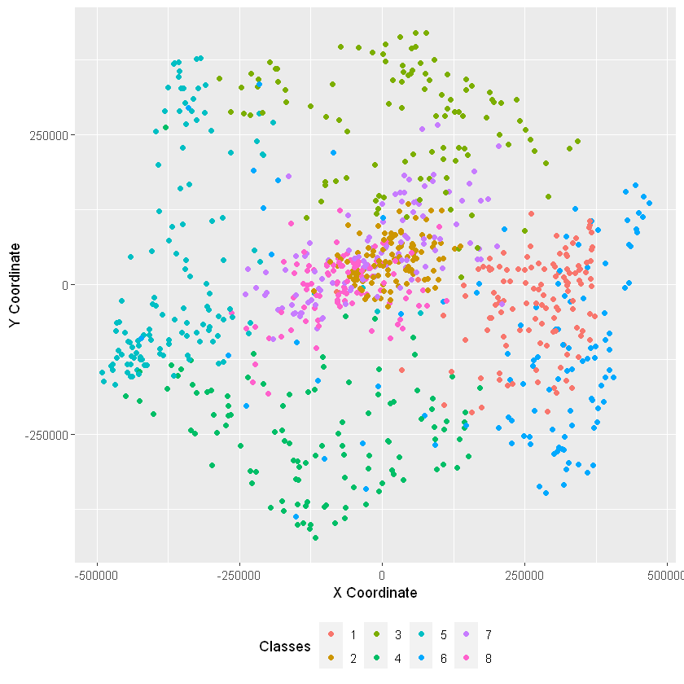

```r
dt<-data.frame(fit$points,df_pos$class)
visualized_dist<-ggplot(dt, aes(x=X1 , y=X2,color=as.factor(df_pos.class)))+geom_point()+labs(color="Classes")+
xlab("X Coordinate")+ylab("Y Coordinate")+theme(legend.position = "bottom")
visualized_dist
```

Location information is used to obtain distance values between the Time Series. All the classes have certain regions. Much as there are some overlaps between the class regions, it is obvious to observe cumulated points with the same class of Time Series. Lastly, distinguishability differs for each class, and for someones becomes hard to classify by just looking at the coordinate values.